# MA end to tend workflow

Bernd Klaus

# 1 Required packages and other preparations

```r
library(BiocStyle)
library(oligo)
library(geneplotter)
library(ggplot2)
library(dplyr)
library(LSD)
library(gplots)
library(RColorBrewer)
library(ArrayExpress)
library(arrayQualityMetrics)
library(stringr)
library(matrixStats)
library(topGO)
library(genefilter)
library(biomaRt)
library(pd.hugene.1.0.st.v1)
library(hugene10sttranscriptcluster.db)
library(pheatmap)
library(mvtnorm)
library(DAAG)
library(multcomp)
library(limma)
library(ReactomePA)
library(clusterProfiler)
library(openxlsx)
library(devtools)
library(biomaRt)
library(EnrichmentBrowser)
#, tempdir()
rawDataDir <- file.path(getwd(), "rawDataMAWorkflow")
```

In this document we introduce a complete workflow for a typical (Affymetrix) microarray analysis. Data import, preprocessing, differential expression and enrichment analysis are discussed. We also introduce some necessary mathematical background along the way.

The data used is from [Palmieri et. al.](http://europepmc.org/abstract/MED/25901971), a paper studying the differences between inflamed and noninflamed colonic mucosa between patients suffering from Ulcerative colitis (UC) or Crohn’s disease (CD). This is a typical clincal data set consiting of 15 CD and 14 UC patients.

# 2 Download the raw data from from ArrayExpress

The first step of the analysis is to download the raw data CEL files. Theses files are produced by the array scanner software and contain the probe intensities measured. The data has been deposited at [ArrayExpress](https://www.ebi.ac.uk/arrayexpress/) and has the accession code **E-MTAB-2967**. This accession code is commonly reported in the original publication.

Each Array–Express data set has a landing page summarizing the data set, the one for our data is here:

- [Data fromPalmieri et. al. at ArrayEpress](https://www.ebi.ac.uk/arrayexpress/experiments/E-MTAB-2967/)

We use the *[ArrayExpress](http://bioconductor.org/packages/release/bioc/html/ArrayExpress.html)* Bioconductor package to obtain the links to download the raw data.

# 3 Information stored in ArrayExpress

In the repository for each dataset ArrayExpress stores a MAGE-TAB document with standardized format. A MAGE-TAB document contains upt to five different types of files Investigation DescriptionFormat (IDF), Array Design Format (ADF), Sample and Data Relationship Format (SDRF), the raw data files and the processed data files.

The Investigation Description Format (IDF) file contains top level information about the experiment including title, description, submitter contact details and protocols. The SDRF (Sample and Data Relationship Format) file containes the information on the samples.

# 4 Get the raw and the annotation data

Wih the code below, we download the raw data from [ArrayExpress](https://www.ebi.ac.uk/arrayexpress/).

It is saved in the directory **rawDataDir** which defaults to the current working directory. The names of the downloaded files are returned as a list.

```r
rawDataDir <- rawDataDir

if(!dir.exists(rawDataDir)){

    dir.create(rawDataDir)
}

annoAE <- getAE("E-MTAB-2967", path=rawDataDir, type="raw")
```

```
   Copying raw data files

   Unpacking data files
```

We now download the SDRF file directly to in order to obtain the sample annotation.

The raw data constists of one CEL file per samples (see below) and we use the .CEL file names as row names. They are given in a column named `Array.Data.File` in the SDRF table. We turn the table into an `AnnotatedDataFrame` from the *[Biobase](http://bioconductor.org/packages/release/bioc/html/Biobase.html)* package that will need later to create an `ExpressionSet` for our data.

```r
SDRF <-  read.delim(url("http://www.ebi.ac.uk/arrayexpress/files/E-MTAB-2967/E-MTAB-2967.sdrf.txt"))

rownames(SDRF) <- SDRF$Array.Data.File
SDRF <- AnnotatedDataFrame(SDRF)
```

Before we move on to the actual data import, we ill briefly introduce this `ExpressionSet` class contained in the *[Biobase](http://bioconductor.org/packages/release/bioc/html/Biobase.html)* package. It is commonly used to store Micorarray data in Bioconductor.

## 4.1 Bioconductor ExpressionSets

Genomic data can be very complex, usually consisting of a number of different bits and pieces. In Bioconductor the approach is taken that these pieces should be stored in a single structure to easily manage the data.

The package *[Biobase](http://bioconductor.org/packages/release/bioc/html/Biobase.html)* contains standardized data structures to represent genomic data. The `ExpressionSet` class is designed to combine several different sources of information into a single convenient structure. An ExpressionSet can be manipulated (e.g., subsetted, copied), and is the input to or output of many Bioconductor functions.

The data in an ExpressionSet consist of

- **assayData**: Expression data from microarray experiments (assayData is used to hint at the methods used to access different data components).
- **metaData**: A description of the samples in the experiment (phenoData), metadata about the features on the chip or technology used for the experiment (featureData), and further annotations for the features, for example gene annotations from biomedical databases (annotation).
- **experimentData**: A flexible structure to describe the experiment.

The ExpressionSet class coordinates all of these data, so that you do not usually have to worry about the details. However, an ExpressionSet needs to be created in the first place, because it will be the starting point for many of the analyses using Bioconductor software.

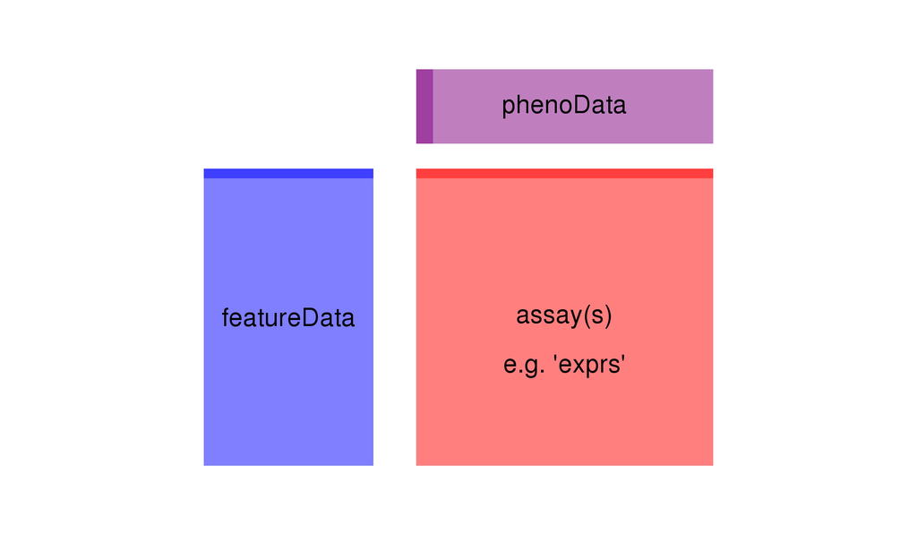

You can use the functions `pData` and `fData` to extract the sample and feature annotation respectively from an `ExpressionSet`. The function `exprs` will return the expression data itself as a matrix.

## 4.2 Import of microarray data and initial quality control

### 4.2.1 Importing CEL files

The microrarray analysis of Affymetrix arrays starts with CEL files. These are the result of processing of the raw image files using the Affymetrix software and contain estimated probe intensity values. Each CEL file contains data on the intensity at each probe on the chip, as well as some other quantities. We collect the information about the CEL files we want to import and then save them in the variable `rawData`.

The followng code results in a character vector with the paths to the CEL files we want to import. the function `read.celfiles` from the *[oligo](http://bioconductor.org/packages/release/bioc/html/oligo.html)* can be used to import the files. The package automatically uses *[pd.hugene.1.0.st](http://bioconductor.org/packages/release/data/annotation/html/pd.hugene.1.0.st.html)* as the chip annotation package.

We specifiy our `AnnotatedDataFrame` created earlier as `phenoData`. We then have to make sure that we import the CEL files in the correct order, for this we use the column `Array.Data.File` of the `SDRF` table.

Finally, we check whether the object created is valid. (e.g. sample names match between the different tables)

```r
celfolder <- rawDataDir

rawData <- read.celfiles(filenames = file.path(rawDataDir, SDRF$Array.Data.File),
                         verbose = FALSE, phenoData = SDRF)
validObject(rawData)
```

We now inspect the raw data a bit, remove some uninteresting phenoData columns and finally retain only those columns that are related to the experimental factors. (IDs of the individuals, disease of the individual and the mucosa type)

```r
head(pData(rawData))
head(exprs(rawData))
stopifnot(validObject(rawData))

pData(rawData) <- pData(rawData)[, c("Source.Name",
                                     "Characteristics.individual.",
                                     "Factor.Value.disease.",
                                     "Factor.Value.phenotype." )]
```

### 4.2.2 Quality control of the raw data

The package *[arrayQualityMetrics](http://bioconductor.org/packages/release/bioc/html/arrayQualityMetrics.html)* produces an html report, containing lots of quality control plots together with a description of their aims. We also check our raw data using this reporting tool. Note that it cannot use more than 10 phenoData columns.

```r
arrayQualityMetrics(expressionset = rawData,
        outdir = "Report_for_Palmieri_raw",
            force = TRUE,
            do.logtransform = TRUE,
            intgroup = c("Factor.Value.disease." ,
                         "Factor.Value.phenotype.")
            )
```

The *[arrayQualityMetrics](http://bioconductor.org/packages/release/bioc/html/arrayQualityMetrics.html)* report shows that the second principal component seems to differentiate between the diseases. The density– and boxplots show that the intensity distributions of the individual arrays are quite different, indicating the need of an appropriate normalization, which we will discuss next.

Basend on the PCA plot we remove the arrays belonging to individuals 255, 2209, 2826, 3262, 3302 and 3332 since arrays that are based on tissues from them have been identified as outliers by at least one method or have an unusual intensity distribution (255 and 2209) compared to the other arrays.

```r
outlierIdx <- pData(rawData)$Characteristics.individual. %in% c( 255, 2209,
                                                                  2826, 3262,
                                                                  3302,3332)
table(outlierIdx)
```

```
   outlierIdx
   FALSE  TRUE
      46    12
```

```r
rawData <- rawData[, !outlierIdx ]
```

# 5 Background adjustment, calibration, summarization and annotation

## 5.1 Within–array normalization

After the initial import and quality assessment, the next step in processing of microarray data is background adjustment. This is essential because part of the measured probe intensities are due to non-specific hybridization and the noise in the optical detection system. Observed intensities need to be adjusted to give accurate measurements of specific hybridization.

## 5.2 Across–array normalization

Without proper normalization, it is impossible to compare measurements from different array hybridizations due to many obscuring sources of variation. These include different efficiencies of reverse transcription, labeling, or hybridization reactions, physical problems with the arrays, reagent batch effects, and laboratory conditions. By looking at the box– and densityplots of the array quality metrics report, we can clearly see that the raw arrays are quite different from each other.

## 5.3 Summarization

After normalization, summarization is needed because transcripts are represented by multiple probes. For each gene, the background adjusted and normalized intensities need to be summarized into one quantity that estimates an amount proportional to the amount of RNA transcript.

You can view its content like this

```r
head(ls("package:hugene10sttranscriptcluster.db"))
```

```
   [1] "hugene10sttranscriptcluster"
   [2] "hugene10sttranscriptclusterACCNUM"
   [3] "hugene10sttranscriptclusterALIAS2PROBE"
   [4] "hugene10sttranscriptclusterCHR"
   [5] "hugene10sttranscriptclusterCHRLENGTHS"
   [6] "hugene10sttranscriptclusterCHRLOC"
```

Additional information is available form the reference manual of the package. Essentially, the package provides a mapping from the manufacturer ids to the annotation.

## 5.4 Old and new “probesets” of Affymetrix microarrays

Traditionally, Affymetrix arrays (the so–called 3’ IVT arrays) were probeset based: a certain fixed group of probes were part of a probeset which represented a certain gene. (However a gene can be represented by multiple probesets)

The modern Gene and Exon arrays are exon based and hence there are two levels of summarization. The exon level summarization is called a “probeset”. However, this probeset is not related at all to the probesets of the old chips, which usually represent a gene as mentioned above. Furthermore, there are also no longer designated match/mismatch probes present on the chip.

To make things even a bit more complicated the “Gene” arrays were created as cheap versions of the “Exon” arrays by taking the “good” probes from the Exon array. So the notion of a probeset is based on the original construction of the probesets on the Exon array, which contains usually at least 4 probes.

But since Affymetrix only took the “good” probes for the Gene arrays, a lot of the probesets on the Gene ST arrays are made up of 3 or fewer probes. Thus, a summarization on the probeset / Exon level is not recommended for gene arrays but still possible by using the database.

## 5.5 One–go preprocessing in oligo

*[oligo](http://bioconductor.org/packages/release/bioc/html/oligo.html)* allows us to perform background correction, normalization and summarization in one single step using a deconvolution method for background correction, quantile normalization and the RMA (robust multichip average) algorithm for summarization.

This package of algorithms as a whole is commonly called RMA algorithm, although strictly speaking RMA is only a summarization method.

```r
palmieriEset <- oligo::rma(rawData, target="core")
```

```
   Background correcting
   Normalizing
   Calculating Expression
```

```r
stopifnot(isTRUE(identical(featureNames(palmieriEset)[c(500, 5500)],
                           c("7893003", "7909954"))))

#save(palmieriEset, file = "palmieriEset.RData")
```

The parameter `target` defines the degree of summarization, the default option “core”, which contains transcript clusters containing “safely” annotated genes. Other options for `target` include “extended” and “full”. For summarization on the exon level (not recommended for Gene arrays), one can use “probeset” as the target option.

An alternative to quantile normalization is the *[vsn](http://bioconductor.org/packages/release/bioc/html/vsn.html)* algorithm, that preforms background correction and normalization by robustly shifting and scaling log–scale intensity values within arrays.

## 5.6 Some mathematical background on normalization/calibration

$Y = B + \alpha \cdot S$

where B is a random quantity due to background noise, usually composed of optical effects and non-specific binding, $\alpha$ is a gain factor, and $S$ is the amount of measured specific binding. The signal $S$ is considered a random variable as well and accounts for measurement error and probe effects. The measurement error is typically assumed to be multiplicative so we write:

$\log(S) = \vartheta + \varphi + \varepsilon$

Here $\vartheta$ represents the logarithm of the true abundance, $\varphi$ is a probe-specific effect, and $\varepsilon$ accounts for measurement error. This is the additive–multiplicative error model for microarray data used by RMA and also the *[vsn](http://bioconductor.org/packages/release/bioc/html/vsn.html)* algorithm. They differ in the way $B$ is removed and an estimate of $\vartheta$ is obtained.

## 5.7 Quality assessment of the calibrated data

After running the RMA algorithm it is a good idea to produce another quality control report.

```r
#load(file.path("dataMAWorkflow", "palmieriEset.RData"))

arrayQualityMetrics(expressionset = palmieriEset,
    outdir = "Report_for_Palmieri_Calibrated",
    force = TRUE,
    do.logtransform = FALSE,
    intgroup = c("Factor.Value.disease." ,
                "Factor.Value.phenotype.")
)
```

Additional potential outliers are identified, however they are close to the other samples on the PCA plot, so we keep them.

We also produce another clustering and PCA plot. In order to display a heatmap of the sample–to–sample distances, we first compute them using the `dist` function. We need to transpose the expresssion values since the function computes the distances between the rows (i.e. genes in our case) by default. The distance chosen is the Eucledian one, however this can of course be changed and we choose the manhatten distance here which uses absolute instead of squared distances. We se the diagonal of the distance matrix to NAs to increase the contrast. Those diagonal entries do not contain information since the distance of a sample to itself is always equal to zero. We then cluster the sample to sample distances again using the manhattan distance to se whether blocks appear in the matrix.

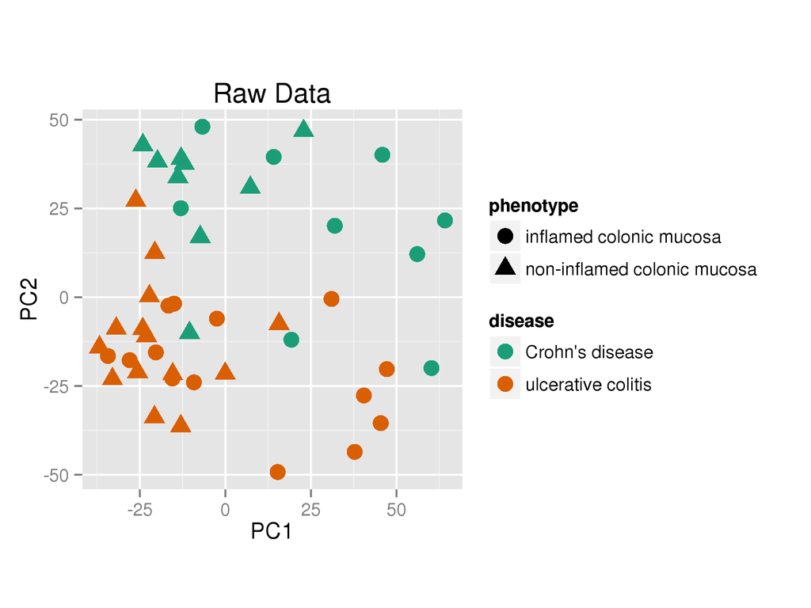

```r
expPalmieri <- exprs(palmieriEset)
PCA <- prcomp(t(expPalmieri), scale = FALSE)

dataGG <- data.frame(PC1 =PCA$x[,1], PC2 = PCA$x[,2],
                    disease = pData(palmieriEset)$Factor.Value.disease.,
                    phenotype = pData(palmieriEset)$Factor.Value.phenotype.
          )
(qplot(PC1, PC2, data = dataGG, color =  disease, shape =  phenotype,
       main = "Raw Data", size = I(4), asp = 1.0  )
 + scale_colour_brewer(palette = "Dark2"))
```

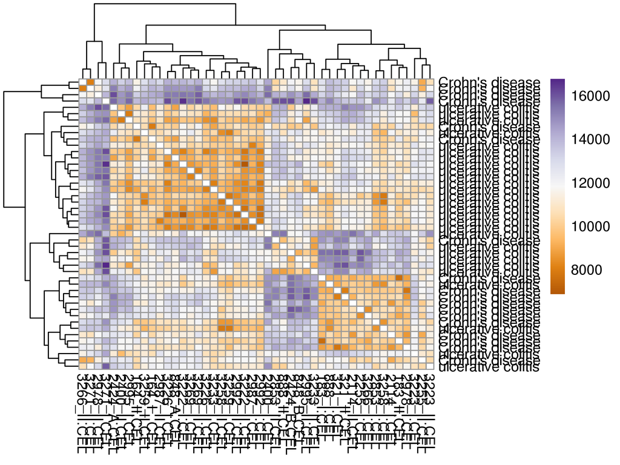

```r
dists <- as.matrix(dist(t(expPalmieri), method = "manhattan" ))
diag(dists) <- NA
rownames(dists) <-  pData(palmieriEset)$Factor.Value.disease.
hmcol <- colorRampPalette( rev(brewer.pal(9, "PuOr")) )(255)


pheatmap(dists, col = rev(hmcol), clustering_distance_rows = "manhattan",
                                 clustering_distance_cols = "manhattan")
```

The second PC now roughly separates Chron’s disease from ulcerative colitis. On the heatmap plot we also see that the samples cluster by disease but not perfectly so, confirming the impression from the PCA plot that the separation between the diseases is not perfect.

## 5.8 Filtering based on intensity

```r
table(pData(palmieriEset)$Factor.Value.disease.)
```

```
      Crohn's disease ulcerative colitis
                   18                 28
```

In our case this would be `table(pData(palmieriEset)$Factor.Value.disease.)[1]`.

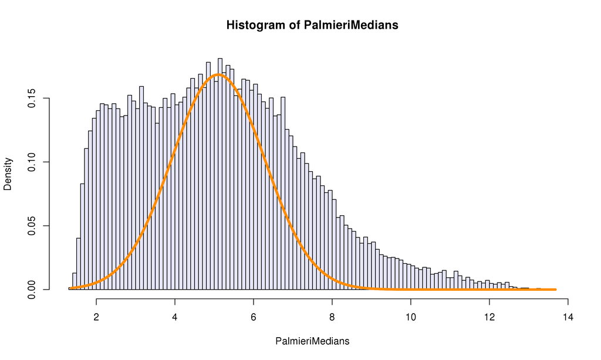

```r
PalmieriMedians <- rowMedians(exprs(palmieriEset))
tmp <- hist(PalmieriMedians, 100, col="lavender", freq = FALSE)

emp_mu <- tmp$breaks[which.max(tmp$density)]
emp_sd <- mad(PalmieriMedians)/2
eta0 <- 0.50

lines(sort(PalmieriMedians), eta0*dnorm(sort(PalmieriMedians),
            mean = emp_mu , sd = emp_sd ),
                col = "darkorange", lwd =4)
```

```r
### find 5% quantile of fitted null model
cut_val <- 0.05 / eta0
thresh_median <- qnorm(0.05 / eta0, emp_mu, emp_sd)


noOfSamples <- table(pData(palmieriEset)$Factor.Value.disease.)[1]
idx_thresh_median <- apply(exprs(palmieriEset), 1, function(x){
    sum(x > thresh_median)  >  noOfSamples
    })
    table( idx_thresh_median)
```

```
   idx_thresh_median
   FALSE  TRUE
    8952 24345
```

```r
PalmieriFiltered <- subset(palmieriEset, idx_thresh_median )
```

## 5.9 Annotation of the transcript clusters

Before we continue with the linear models for microarrays and differential expression we describe how to add ``feature Data“, i.e. annotation information to the transcript clusters. We use the from *[AnnotationDbi](http://bioconductor.org/packages/release/bioc/html/AnnotationDbi.html)* to query the gene symbols and associated short descriptions for the transcript clusters.

```r
annoPalmieri <- AnnotationDbi::select(hugene10sttranscriptcluster.db,
                                  keys=(featureNames(PalmieriFiltered)),
                                  columns = c("SYMBOL", "GENENAME"),
                                  keytype="PROBEID")
```

```r
#listMarts(host="www.ensembl.org")
#HSmart <- useMart(biomart="ENSEMBL_MART_ENSEMBL", dataset="hsapiens_gene_ensembl", host="www.ensembl.org")
# affy_hugene_1_0_st_v1

# get probeset IDs for transcript cluster 2315633
# huex <- read.table("~/Downloads/HuEx-1_0-st-v2.na32.hg19.probeset.csv", sep = ",", stringsAsFactors = F, header = T)
# probes <- subset(huex, transcript_cluster_id == "2315633")$probeset_id
# # get gene symbols
# genes <- getBM(attributes = c("affy_huex_1_0_st_v2", "hgnc_symbol"), filters = "affy_huex_1_0_st_v2", values = probes, mart = mart.hs)
# genes
```

## 5.10 Removing multiple mappings and building custom annotations

Many transcript–cluster IDs will map to multiple gene symbols. We compute a summary table in the code below to see how many there are.

```r
probeStats <- annoPalmieri  %>%
    group_by(PROBEID) %>%
    summarize(noOfMatches = n_distinct(SYMBOL)) %>%
    filter( noOfMatches > 1)

probeStats
```

```
   Source: local data frame [2,185 x 2]

      PROBEID noOfMatches
        (chr)       (int)
   1  7896742           8
   2  7896754           2
   3  7896937           3
   4  7896952           2
   5  7896961           3
   6  7897006           2
   7  7897632           3
   8  7897745           2
   9  7897953           2
   10 7897991           2
   ..     ...         ...
```

```r
dim(probeStats)
```

```
   [1] 2185    2
```

We have over 2000 transcript–clusters that map to multiple gene symbols. It is diffcult to decide which mapping is “correct”. Therefore, we exclude these transcript–clusters. Additionally, we also exclude transcript–clusters that do not map to gene symbols.

```r
IDsToExlude <- ((featureNames(PalmieriFiltered) %in% probeStats$PROBEID) |
               featureNames(PalmieriFiltered)  %in% subset(annoPalmieri,
                                                           is.na(SYMBOL))$PROBEID)
table(IDsToExlude)
```

```
   IDsToExlude
   FALSE  TRUE
   16906  7439
```

```r
PalmieriFinal <- subset(PalmieriFiltered, !IDsToExlude )

validObject(PalmieriFinal)
```

```
   [1] TRUE
```

```r
fData(PalmieriFinal)$PROBEID <- rownames(fData(PalmieriFinal))
fData(PalmieriFinal) <- left_join(fData(PalmieriFinal), annoPalmieri)
# restore rownames
rownames(fData(PalmieriFinal)) <-fData(PalmieriFinal)$PROBEID

validObject(PalmieriFinal)
```

```
   [1] TRUE
```

```r
#save(PalmieriFinal, file = "PalmieriFinal.RData")
```

Alternatively, one can re–map the probes of the array to a current annotation, a workflow to do to this for Illumina arrays is given in

[Arloth et. al.](https://dx.doi.org/10.1371/journal.pone.0139516)

Essentially, the individual probe sequences are re–aligned to an in–silico “exome” that consists of all annotated transcript exons.

In any case, the package *[pdInfoBuilder](http://bioconductor.org/packages/release/bioc/html/pdInfoBuilder.html)* can be used to build custom annotation packages for use with *[oligo](http://bioconductor.org/packages/release/bioc/html/oligo.html)*. In order to do this, PGF / CLF files (named ``Library files’’ on the Affymetrix website) as well as the probeset annotations are required. The probesets typically represent a small streches of the genome (such as a single exon) and multiple probesets are then used to form a transcript cluster.

The CLF file contains information about the location of individual probes on the array. The PGF file then contains the individual probe sequences and shows the probeset they belong to. Finally, The probset annotation .csv then finally contains information about which probesets are used in which transcript cluster. Commonly, multiple probesets are used in one transcript cluster and some probesets are contained in multiple transcript clusters.

# 6 A short overview of linear models

I am afraid this section is rather technical. However general experience shows that most questions on the internet regarding packages on Bioconductor using linear models like *[limma](http://bioconductor.org/packages/release/bioc/html/limma.html)*, *[DESeq2](http://bioconductor.org/packages/release/bioc/html/DESeq2.html)* and *[edgeR](http://bioconductor.org/packages/release/bioc/html/edgeR.html)* are actually not so much about the packages themselves but rather about the underlying linear models. It might also be helpful to learn a bit of linear algebra to understand the concepts better. The Khan Academy [offers nice (and free) online courses](https://www.khanacademy.org/math/linear-algebra).

Mike Love’s and Michael Irizzary’s [genomics class](http://genomicsclass.github.io/book/) is also a very good resource, especially its section on [interactions and contrasts](http://genomicsclass.github.io/book/pages/interactions_and_contrasts.html).

## 6.1 Regression models

In regression models we use one variable to explain or predict the other. It is customary to plot the predictor variable on the x–axis and the predicted variable on the y-axis. The predictor is also called the independent variable, the explanatory variable, the covariate, or simply x. The predicted variable is called the dependent variable, or simply y.

In a regression problem the data are pairs $(x_i , y_i )$ for $i = 1, \dotsc , n$. For each $i, y_i$ is a random variable whose distribution depends on $x_i$. We write

$y_i = g(x_i) + \varepsilon_i .$

The above expresses $y_i$ as a systematic or explainable part $g(x_i)$ and an unexplained part $\varepsilon_i$. Or more informally: response = signal + noise. $g$ is called the regression function. Often the goal is to estimate $g$. As usual, the most important tool to infer a suitable function is a simple scatterplot. Once we have an estimate $\hat g$ of $g$, we can compute $r_i := y_i - g(x_i )$. The $r_i$ ’s are called residuals. The $\varepsilon_i$’s themselves are called errors.

Residuals are used to evaluate and assess the fit of models for g. Usually one makes distributional assumption about them, e.g. that they are i.i.d. normally distributed with identical variance $\sigma^2$ and mean zero:

$r_i \sim N(0, \sigma^2)$

This allows to derive statistical tests for model coefficients.

## 6.2 Linear regression models

Linear regression is a special case of the general regression model. Here, we combine the predictors linearly to produce a prediction. If we have only single predictor $x$, the simple linear regression model is:

$y_i = \beta_0 + \beta_1 x_{ij} + \varepsilon_i; \quad \varepsilon_i \sim N(0, \sigma);$

We can of course always add more predictors, let their total number be denoted by $p$. Then we get a multiple linear regression:

$y_i= \beta_0 + \sum_{j=1}^p \beta_j x_{i} + \varepsilon_i; \quad j=1,...,p$

The equation for a multiple linear regression model can also be written in matrix form. (We will also denote matrices and vectors in bold font).

$\mathbf{Y}_{n \times 1} = \mathbf{X}_{n \times (p+1)} \mathbf{\beta}_{(p+1) \times 1} + \mathbf{\varepsilon}_{n \times 1}$

With $\mathbf{X}$ being the so called **design matrix**

$\mathbf{X}:= \bigl( \mathbb{1}_n, X_1, \dotsc, X_p\bigr)$

$\mathbb{1}_n$ is a columns vector of ones called the **intercept** and X_p = (x_{p1}, , x_{pn})^T is a column vector of measurements for covariate $p$. The regression coefficients are commonly estimated by the method of ``ordinary least squares" (OLS):

$\text{OLS:} \bigl|\bigl| Y - \beta_0 - \sum_{j=1}^p \beta_j X_{j} \bigl|\bigl|_E \rightarrow \min!$

leading to the estimate of the coefficient vector

$\hat \beta = ( \mathbf{X}^T \mathbf{X})^{-1} \mathbf{X}^TY$

$\hat \beta = \text{Diag}(c_1, \dotsc c_p) \mathbf{X}^TY = \bigl(X_1, \dotsc, X_p\bigr)^TY$

So that the fitted values for individual coefficients $\hat \beta_j, \; j \in \{0, \dotsc, p\}$ are independent of all the other coefficients. This is a very desirable feature and also leads to computational efficiency: Instead of fitting a multiple regression, we can as well fit a simple regression for each of the covariates separately.

## 6.3 Creating design matrices in R

Parts of this section are based on material by Mike Love. To get an idea of what design matrices look like, we consider several examples. It is important to know some fundamentals about design matrices in order to be able to correctly transfer a design of a particular study to an appropriate linear model.

We will use the base R functions:

- `formula`
- `model.matrix`

…in order to produce design matrices for a variety of linear models. R uses the formula interface to create design matrices automatically. In the first example, we have two groups of 2 samples each. Using and we will create a model matrix with so called treatment contrast parameterization (the default setting in R). This means that an intercept is included in the model, i.e. $X_0 = \mathbb{1}_n$ and $X_1$ is equal to 1 if the samples belongs to group two and zero otherwise as we can the see in the R output.

```r
two.groups <- factor(c(1,1,2,2))
f <- formula(~ two.groups)
model.matrix(f)
```

```
     (Intercept) two.groups2
   1           1           0
   2           1           0
   3           1           1
   4           1           1
   attr(,"assign")
   [1] 0 1
   attr(,"contrasts")
   attr(,"contrasts")$two.groups
   [1] "contr.treatment"
```

```r
#model.matrix(f, contrasts.arg=list(two.groups="contr.sum", contrasts = FALSE))
```

This design is called treatment contrast parameterization for an obvious reason: the first column of the design matrix represents a ``base level“, i.e the mean $\beta_0$ for group one and the second column, corresponding to $\beta_1$, represents the difference between the group means since all group two samples have means $\beta_0 + \beta_1$. Since $\beta_0$ is the mean of group 1, $\beta_1$ must correspond to the difference of the means of group two and group one and thus shows the effect of a”treatment“.

However, this design is not orthogonal. We can construct an equivalent orthogonal design as follows:

```r
gr1 <- ifelse(two.groups == 1, 1,0)
gr2 <- ifelse(two.groups == 2, 1,0)
orth.model <- model.matrix(~ 0 + gr1 + gr2)
#crossprod(orth.model,orth.model)
```

Here, we loose the nice direct interpretability of the coefficients. Now $\beta_1$ is simply the mean of the second group. We will discuss the extraction of interesting contrasts from a model like this below.

We explicitly excluded the intercept by specifying it as zero. Commonly it makes sense to include an intercept in the model, especially in more complex models.

We can also specify a more complex design easily: if we have two independent factors, the base mean now corresponds to the first levels of the two factors.

```r
x <- factor(c(1,1,1,1,2,2,2,2))
y <- factor(c("a","a","b","b","a","a","b","b"))
two.factors <- model.matrix(~ x + y)
two.factors
```

```
     (Intercept) x2 yb
   1           1  0  0
   2           1  0  0
   3           1  0  1
   4           1  0  1
   5           1  1  0
   6           1  1  0
   7           1  1  1
   8           1  1  1
   attr(,"assign")
   [1] 0 1 2
   attr(,"contrasts")
   attr(,"contrasts")$x
   [1] "contr.treatment"

   attr(,"contrasts")$y
   [1] "contr.treatment"
```

The ``drop one" strategy is the default method for creating regression coefficients from factors in R. If a factor has $d$ levels, adding it to the model will give you $d-1$ regression coefficients corresponding to $d-1$ columns in a design matrix.

Apart from excluding the intercept, you can also use the `I` function to treat a covariate as it is without using the formula syntax. The code below includes $z^2$ as covariate.

```r
z <- 1:4
model.matrix(~ z)
```

```
     (Intercept) z
   1           1 1
   2           1 2
   3           1 3
   4           1 4
   attr(,"assign")
   [1] 0 1
```

```r
model.matrix(~ 0 + z)
```

```
     z
   1 1
   2 2
   3 3
   4 4
   attr(,"assign")
   [1] 1
```

```r
model.matrix(~ z + I(z^2))
```

```
     (Intercept) z I(z^2)
   1           1 1      1
   2           1 2      4
   3           1 3      9
   4           1 4     16
   attr(,"assign")
   [1] 0 1 2
```

## 6.4 Singular model matrices

For factor models, this happens if two conditions are confounded, e.g. in one experimental group there are only females and in the other group there are only males. Then the effect of sex and experimental group cannot be disentangled.

Let’s look at an example. We set three factors, of which the third one is nested with the first two. We can check the singularity of the model matrix by computing its so called singular value decomposition and check it’s minimal singular value. If this is zero, the matrix is singular. As we can see, this is indeed the case here.

```r
x <- factor(c(1,1,1,1,2,2,2,2))
y <- factor(c("a","a","b","b","a","a","b","b"))
z <- factor(c("m","m","m","m","k","k","l","l"))
sing.model <- model.matrix(~ x+y+z)
sing.model
```

```
     (Intercept) x2 yb zl zm
   1           1  0  0  0  1
   2           1  0  0  0  1
   3           1  0  1  0  1
   4           1  0  1  0  1
   5           1  1  0  0  0
   6           1  1  0  0  0
   7           1  1  1  1  0
   8           1  1  1  1  0
   attr(,"assign")
   [1] 0 1 2 3 3
   attr(,"contrasts")
   attr(,"contrasts")$x
   [1] "contr.treatment"

   attr(,"contrasts")$y
   [1] "contr.treatment"

   attr(,"contrasts")$z
   [1] "contr.treatment"
```

```r
round(min(svd(sing.model)$d))
```

```
   [1] 0
```

Here the we have one column in the design matrix that can be represented by a linear combination of the other columns, thus the column space has actually a lower dimension than the apparent one. For example, we can represent column 5 (“zm”) by a linear combination of the first two columns “intercept” and “x2”:

```r
comb.coefs  <- coef(lm(sing.model[,5] ~ 0 + sing.model[,-5]))
comb.coefs <-  ifelse(is.na(comb.coefs), 0L, comb.coefs)
comb.coefs
```

```
   sing.model[, -5](Intercept)          sing.model[, -5]x2
                      1.00e+00                   -1.00e+00
            sing.model[, -5]yb          sing.model[, -5]zl
                      2.36e-16                   -2.36e-16
```

```r
round(sum(sing.model[,-5] %*% comb.coefs - sing.model[,5]))
```

```
   [1] 0
```

I.e., in mathematical notation this means $\begin{pmatrix} 1\\1\\1\\1\\0\\0\\0\\0 \end{pmatrix} = 1\cdot \begin{pmatrix} 1\\1\\1\\1\\1\\1\\1\\1 \end{pmatrix} -1\cdot \begin{pmatrix} 0\\0\\0\\0\\1\\1\\1\\1 \end{pmatrix}$

Thus the corresponding regression coefficients are not uniquely determined and the model does not make much sense. The function handles a singular design matrix quite intelligently, it will remove a dependant column. We now explore this by simulating some normally distributed random numbers and fitting a model to this data using our matrix.

```r
lm(rnorm(8) ~ 0 + sing.model)
```

```
   Call:
   lm(formula = rnorm(8) ~ 0 + sing.model)

   Coefficients:
   sing.model(Intercept)           sing.modelx2           sing.modelyb
                   0.089                 -0.427                 -0.135
            sing.modelzl           sing.modelzm
                   1.224                     NA
```

This is also true if we have numerical dependent data, as in the following example:

```r
sing.real <- data.frame(x = t(rmvnorm(1, mean= sort(rep(8:9,4)))),
                       y = t(rmvnorm(1, mean= rep(c(rep(4,2), rep(5,2)),2))))
sing.real <- mutate(sing.real, z = y-2*x)
min(svd(sing.real)$d)
```

```
   [1] 2.62e-15
```

```r
round(sing.real <- mutate(sing.real, target = x + y + z + rnorm(8)))
```

```
     x y   z target
   1 9 1 -18     -7
   2 8 2 -13      0
   3 8 6  -9      6
   4 8 2 -14     -3
   5 8 4 -11      0
   6 8 4 -13      0
   7 8 6 -10      2
   8 9 4 -14      0
```

```r
lm(target ~ x + y+ z, data = sing.real)
```

```
   Call:
   lm(formula = target ~ x + y + z, data = sing.real)

   Coefficients:
   (Intercept)            x            y            z
          6.07        -1.49         1.58           NA
```

R removes z, which is just a linear combination of x and y. Note however, that the ordinary least squares fit will always “work”, whether the model matrix is singular or not. This might give results requiring careful interpretation in some cases. E.g., there is nothing special about z. We could have excluded y or x as well instead of z.

Therefore, the non–singularity of the model matrix should always be checked beforehand.

## 6.5 Using contrasts to test hypotheses in linear regression

In differential expression analysis, our most important covariates will be factors that differentiate between two or more groups, e.g. the covariate $X_p = (\bx_{p1}, \dotsc, \bx_{pn})$ is either zero or one depending on which group the sample belongs to.

We transform car into a factor so that R performs the necessary parameterization of the contrasts automatically.

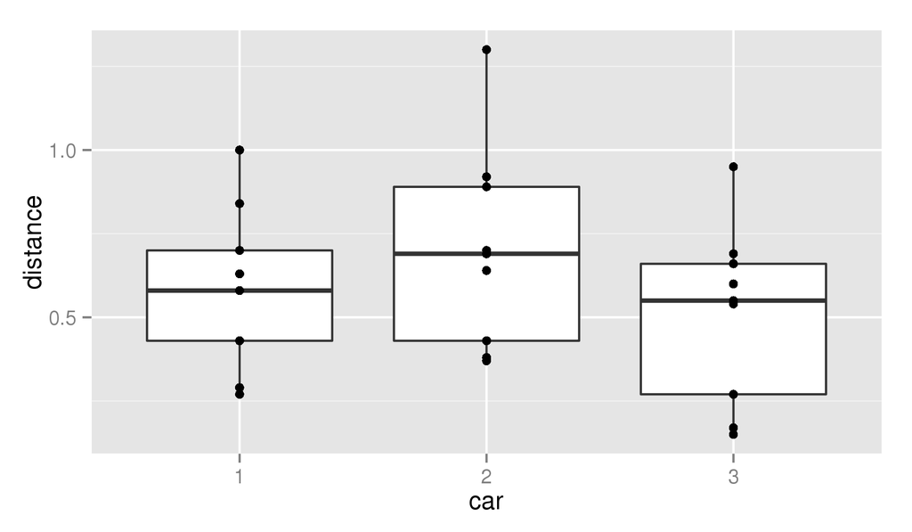

```r
toycars$car = as.factor(toycars$car)
qplot(car, distance, data = toycars, geom="boxplot") + geom_point()
```

By looking at the box plots of distance by car, we can clearly see differences between the three types of cars. We can now fit a linear model with distance as the dependent variable and car and angle as the predictors. As we can see from the linear model output, the treatment contrast parameterization was used, with car 1 being the base level.

```r
lm.car <- lm(distance~angle+car, data = toycars)
summary(lm.car)
```

```
   Call:
   lm(formula = distance ~ angle + car, data = toycars)

   Residuals:
        Min       1Q   Median       3Q      Max
   -0.09811 -0.04240 -0.00669  0.01741  0.17251

   Coefficients:
               Estimate Std. Error t value Pr(>|t|)
   (Intercept)  0.09252    0.03467    2.67    0.014 *
   angle        0.18854    0.00995   18.96  1.5e-15 ***
   car2         0.11111    0.03195    3.48    0.002 **
   car3        -0.08222    0.03195   -2.57    0.017 *
   ---
   Signif. codes:  0 '***' 0.001 '**' 0.01 '*' 0.05 '.' 0.1 ' ' 1

   Residual standard error: 0.0678 on 23 degrees of freedom
   Multiple R-squared:  0.945,  Adjusted R-squared:  0.938
   F-statistic:  132 on 3 and 23 DF,  p-value: 1.22e-14
```

## 6.6 Testing general linear hypotheses

The estimated coefficients now give us the difference between the distance traveled between car 1 and car 2 (0.11) and car 1 and car 3 (-0.08), and the associated t–tests of these coefficients. However we cannot see a test of car 2 vs. car 3. This contrast test would correspond to testing the difference between the car2 and car3 regression coefficients.

Thus, contrasts of interest to us may not be readily correspond to coefficients in a fitted linear model. However, one can easily test general linear hypotheses of the coeffecients of the form:

$H_0: \mathbf{C}_{ q \times (p+1) } \mathbf{\beta}_{ (p+1) \times 1 } = \mathbf{\alpha}_{ q \times 1 }$

Where $\mathbf{C}$ is the contrast matrix containing the between group differences of interest, $q$ is the total number of comparisons to be performed and $\mathbf{alpha}$ contains the difference to be tested, this is usually a vector of zeros. If one tests multiple coeficients at once (e.g. $\beta_1 = 0$ and $\beta_2 = 0$ the corresponding test statistic is $F$–distributed and if one just tests linear combinations of coefficients, e.g. $\beta_1 - \beta_2 = 0$, $\beta_1 - \beta_2 - 2\beta_3 = 0$ or something like that the test statistic has t–distribution. The function `summary` reports the results of $\beta_1 = \beta_2 = \dotso = \beta_p = 0$ (F–test) and the t–tests of $\beta_j = 0$ each of the coefficients.

Not that the model does not actually have to be refitted in order to test the contrasts. This makes contrast matrix based testing more efficient and convenient than reformulating the model using a new paramerization of the factors to obtain the desired tests.

We can use the function `glht` from the *[multcomp](http://cran.fhcrc.org/web/packages/multcomp/index.html)* to test these general linear hypotheses. Let us assume we want all pairwise comparisons between the cars, this can be achieved by defining a contrast specific matrix for our current model given below.

There are 3 such comparisons and we can print the results by using the `summary` function. As we can see the estimates for the contrasts already contained in the original model agree with the obtained results.

```r
C <- rbind(c(0,0,1,0), c(0,0,0,1), c(0,0, 1,-1) )
colnames(C) <- rownames(summary(lm.car)$coefficients)
rownames(C) <- c("car2 - car1", "car3 - car1" , "car2 - car3" )
C
```

```
               (Intercept) angle car2 car3
   car2 - car1           0     0    1    0
   car3 - car1           0     0    0    1
   car2 - car3           0     0    1   -1
```

```r
summary(glht(lm.car, C), test = adjusted(type ="none"))
```

```
     Simultaneous Tests for General Linear Hypotheses

   Fit: lm(formula = distance ~ angle + car, data = toycars)

   Linear Hypotheses:
                    Estimate Std. Error t value Pr(>|t|)
   car2 - car1 == 0   0.1111     0.0320    3.48    0.002 **
   car3 - car1 == 0  -0.0822     0.0320   -2.57    0.017 *
   car2 - car3 == 0   0.1933     0.0320    6.05  3.6e-06 ***
   ---
   Signif. codes:  0 '***' 0.001 '**' 0.01 '*' 0.05 '.' 0.1 ' ' 1
   (Adjusted p values reported -- none method)
```

Usually, the contrast matrix is assumed to have full rank. The introduction of an intercept in our model creates a redundancy that has to be resolved. Also, the metric covariate has to be taken into account. The function does this automatically for us. Commonly, one uses a model without an intercept and extracts contrasts of interest as we will see later when using *[limma](http://bioconductor.org/packages/release/bioc/html/limma.html)* and in the exercise below.

Note that the term “contrast” is used in the context of (re)parameterization of the original model (as in “treatment contrasts”) and in the testing of linear hypotheses about the model coefficients. This can lead to some confusion, however usually it should be clear from the context whether a reparameterization or test of linear hypotheses is intended.

# 7 Linear models for microarrays

We now apply linear models to microarrays. Specifically, we discuss how to use the *[limma](http://bioconductor.org/packages/release/bioc/html/limma.html)* for differential expression analysis. The package is designed to analyze complex experiments involving comparisons between many experimental groups simultaneously while remaining reasonably easy to use for simple experiments.

The central idea is to fit a linear model to the expression data for each gene. Empirical Bayes and other shrinkage methods are used to borrow information across genes making the analyses stable even for experiments with small number of arrays.

As introduced above, we use appropriate design and contrast matrices for our linear models and fit a linear model to each gene separately.

## 7.1 A linear model for the data

The original paper was interersted in changes in transcription that occur between inflamed and adjacent noninflamed mucoasal areas of the colon in both inflamatory bowel disease types studied.

Since we have two arrays per individual, the first factor we need is a blocking factor for the individuals that will absorb differences between them. Then we create a factor that gives us the combination of disease and the tissue type and allows use to identify differentially expressed genes between the tissues types in the two diseases. We simpify the names of the diseases. Then, we create two design matrices, one for each of the two diseaeses.

```r
#load(file.path("dataMAWorkflow", "PalmieriFinal.RData"))

individual <- as.character(pData(PalmieriFinal)$Characteristics.individual.)

tissue <- str_replace_all(pData(PalmieriFinal)$Factor.Value.phenotype., " ", "_")
tissue <- ifelse(tissue == "non-inflamed_colonic_mucosa", "nI", "I")

disease <- str_replace_all(pData(PalmieriFinal)$Factor.Value.disease., " ", "_")
disease <- ifelse(disease == "Crohn's_disease", "C", "U")


i <- individual[disease == "C"]
designPalmieriC <- model.matrix(~ 0  + tissue[disease == "C"]
                                + i)
colnames(designPalmieriC)[1:2] <- c("I", "nI")


i <- individual[disease == "U"]
designPalmieriU <- model.matrix(~ 0  + tissue[disease == "U"]
                                + i)
colnames(designPalmieriU)[1:2] <- c("I", "nI")
```

We can now inspect the design matrices and test their rank.

```r
head(designPalmieriC[, 1:6])
```

```
     I nI i183 i2114 i2255 i2853
   1 0  1    0     0     0     0
   2 1  0    0     0     0     0
   3 0  1    1     0     0     0
   4 1  0    1     0     0     0
   5 0  1    0     1     0     0
   6 1  0    0     1     0     0
```

```r
dim(designPalmieriC)
```

```
   [1] 18 10
```

```r
head(designPalmieriU[, 1:6])
```

```
     I nI i2424 i2987 i2992 i2995
   1 0  1     0     0     0     0
   2 1  0     0     0     0     0
   3 0  1     1     0     0     0
   4 1  0     1     0     0     0
   5 0  1     0     1     0     0
   6 1  0     0     1     0     0
```

```r
dim(designPalmieriU)
```

```
   [1] 28 15
```

## 7.2 Contrasts and hypotheses tests

We can now fit the linear model and define appropriate contrasts to test hypotheses of interest. We want to compare the inflammed to the the non–inflammed tissue. We create a contrast matrix consisting of one line. *[limma](http://bioconductor.org/packages/release/bioc/html/limma.html)*s function does this for us. We can fit the linear model, compute the moderated $t$–statistics by calling the function and finally extract the number of differentially expressed genes while controlling the FDR by requiring BH–corrected p–value below a certain threshold.

```r
contrastMatrixC <- makeContrasts(I-nI, levels = designPalmieriC)

PalmieriFitC <- eBayes(contrasts.fit(lmFit(PalmieriFinal[,disease == "C"],
                                design = designPalmieriC),
                                contrastMatrixC))

contrastMatrixU <- makeContrasts(I-nI, levels = designPalmieriU)

PalmieriFitU <- eBayes(contrasts.fit(lmFit(PalmieriFinal[,disease == "U"],
                                design = designPalmieriU),
                                contrastMatrixU))
```

## 7.3 Extracting results

Results can be extracted by use of the `topTable` function. We extract the comparisons for both Chron’s disease as well as u and sort the results by their $t$–statistics. As a diagnostic check, we also plot the $p$–value histogram: We excpect a uniform distribution for the p–values that correspond to true null hypotheses, while the a peak near zero shows a enrichment for low p–values corresponding to differentially expressed (DE) genes. A p–value less than 0.001 was used in the original paper as a significance cutoff leading to 298 (CD) and 520 (UC) DE–genes for the two diseases.

We call around 1000 genes in both conditions at the same cutoff, this is probably due to the increased power from the blocking according to the individuals and the moderated variance estimation that *[limma](http://bioconductor.org/packages/release/bioc/html/limma.html)* performs.

```r
tableC <-  topTable(PalmieriFitC, number = Inf)
head(tableC)
```

```
           PROBEID   SYMBOL
   8169504 8169504  SLC6A14
   8021584 8021584 SERPINB5
   8080964 8080964   GXYLT2
   8073015 8073015   KDELR3
   8102800 8102800  SLC7A11
   7954527 7954527   ARNTL2
                                                                                              GENENAME
   8169504                                 solute carrier family 6 (amino acid transporter), member 14
   8021584                                   serpin peptidase inhibitor, clade B (ovalbumin), member 5
   8080964                                                              glucoside xylosyltransferase 2
   8073015                   KDEL (Lys-Asp-Glu-Leu) endoplasmic reticulum protein retention receptor 3
   8102800 solute carrier family 7 (anionic amino acid transporter light chain, xc- system), member 11
   7954527                                       aryl hydrocarbon receptor nuclear translocator-like 2
            logFC AveExpr      t  P.Value adj.P.Val     B
   8169504  4.659    6.51  19.52 6.37e-11  1.08e-06 13.30
   8021584  2.339    5.04  13.22 7.54e-09  6.37e-05 10.04
   8080964 -1.266    5.32 -12.34 1.72e-08  9.71e-05  9.39
   8073015  0.949    6.90  11.01 6.63e-08  2.80e-04  8.29
   8102800  1.686    5.73   9.37 4.25e-07  1.22e-03  6.69
   7954527  1.251    5.64   9.35 4.32e-07  1.22e-03  6.67
```

```r
table(tableC$adj.P.Val < 0.05)
```

```
   FALSE  TRUE
   14932  1974
```

```r
table(tableC$P.Value < 0.001)
```

```
   FALSE  TRUE
   15977   929
```

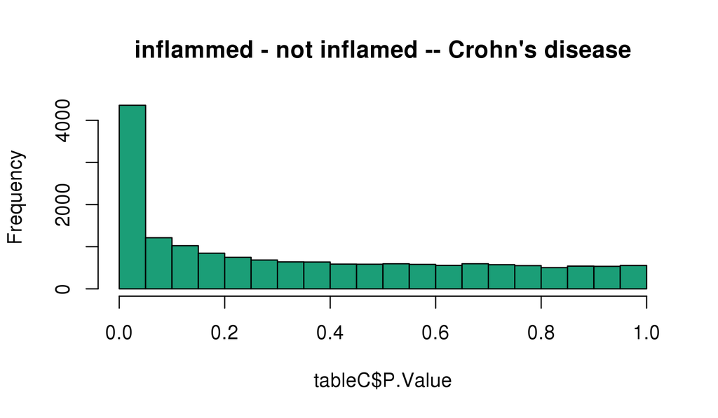

```r
hist(tableC$P.Value, col = brewer.pal(3, name = "Dark2")[1],
     main = "inflammed - not inflamed -- Crohn's disease")
```

```r
tableU <-  topTable(PalmieriFitU, number = Inf)
head(tableU)
```

```
           PROBEID   SYMBOL
   8082012 8082012  SLC15A2
   8003875 8003875    SPNS2
   8122734 8122734 PPP1R14C
   8096070 8096070     BMP3
   7961693 7961693     LDHB
   8133938 8133938     CROT
                                                                GENENAME  logFC
   8082012 solute carrier family 15 (oligopeptide transporter), member 2  0.802
   8003875                               spinster homolog 2 (Drosophila)  0.731
   8122734     protein phosphatase 1, regulatory (inhibitor) subunit 14C -0.557
   8096070                                  bone morphogenetic protein 3 -1.709
   7961693                                       lactate dehydrogenase B  0.401
   8133938                               carnitine O-octanoyltransferase -0.739
           AveExpr     t  P.Value adj.P.Val    B
   8082012    5.35  8.07 1.99e-07   0.00187 7.22
   8003875    6.50  7.80 3.22e-07   0.00187 6.79
   8122734    7.17 -7.64 4.31e-07   0.00187 6.53
   8096070    6.38 -7.63 4.42e-07   0.00187 6.50
   7961693    9.59  7.46 6.01e-07   0.00201 6.22
   8133938    6.36 -7.37 7.13e-07   0.00201 6.07
```

```r
table(tableU$adj.P.Val < 0.05)
```

```
   FALSE  TRUE
   14683  2223
```

```r
table(tableU$P.Value < 0.001)
```

```
   FALSE  TRUE
   15941   965
```

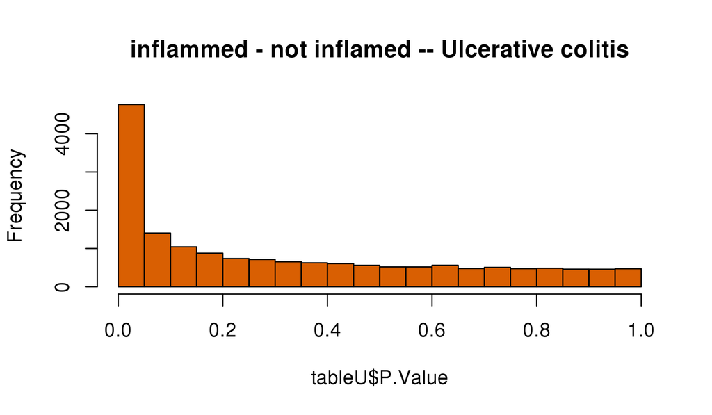

```r
hist(tableU$P.Value, col = brewer.pal(3, name = "Dark2")[2],
     main = "inflammed - not inflamed -- Ulcerative colitis")
```

## 7.4 Comparion to the paper results

```r
#download.file("http://links.lww.com/IBD/A795", destfile = "PalmieriDERes.xls")
PalmieriDERes <- sapply(1:4, function(i) read.xlsx(cols = 1,
"PalmieriDERes.xlsx", sheet = i, startRow = 4))


names(PalmieriDERes) <- c("CD_UP", "CD_DOWN", "UC_UP", "UC_DOWN")
PalmieriDERes <- lapply(PalmieriDERes, as.character)
paperDEgenesCD <- Reduce("c", PalmieriDERes[1:2])
paperDEgenesUC <- Reduce("c", PalmieriDERes[3:4])

overlapCD <- length(intersect(subset(tableC, P.Value < 0.001)$SYMBOL,  paperDEgenesCD)) /
    length(paperDEgenesCD)


overlapUC <- length(intersect(subset(tableU, P.Value < 0.001)$SYMBOL,  paperDEgenesUC)) /
    length(paperDEgenesUC)
```

# 8 Gene ontology (GO) based enrichment analysis

We can now try characterize the identified differentially expressed genes a bit better by performing an GO enrichment analysis. Essentially the gene ontology (http://www.geneontology.org/) is a hierarchically organized collection of functional gene sets. For a nice introduction to the GO see [du Plessis et. al.](http://www.dx.doi.org/10.1093/bib/bbr002).

## 8.1 Matching the background set

The function `genefinder` from the *[genefilter](http://bioconductor.org/packages/release/bioc/html/genefilter.html)* will be used to find background genes that are similar to the differentially expressed genes. We then check whether the background has roughly the same distribution of average expression strength as the foreground.

We do this in order not to select a biased background since the gene set testing is performed by a simple Fisher test on a 2x2 table. Note that this appraoch is very similar to web tools like DAVID. Here we focus on the CD data.

For every differentially expressed gene, we try to find genes with similar expresssion.

```r
DEgenesCD <- subset(tableC, adj.P.Val < 0.1)$PROBEID

backGIdx <- genefinder(PalmieriFinal, as.character(DEgenesCD),
                       method="manhattan", scale="none")

backGIdx <- sapply(backGIdx, function(x)x$indices)

backG <-featureNames(PalmieriFinal)[backGIdx]
backG <- setdiff(backG, DEgenesCD)


intersect(backG, DEgenesCD)
```

```
   character(0)
```

```r
length(backG)
```

```
   [1] 9242
```

```r
   multidensity( list(
        all=  tableC[,"AveExpr"] ,
        fore= tableC[DEgenesCD, "AveExpr"],
        back= tableC[rownames(tableC) %in% backG, "AveExpr"]),
     xlab="mean expression",
   main = "DE genes for CD - Background - Matching")
```

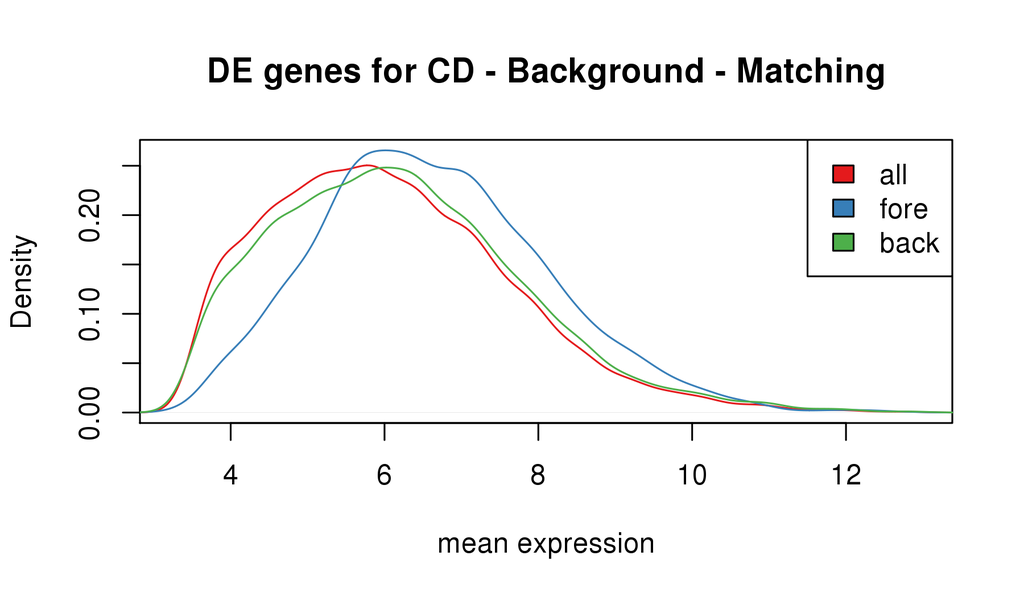

The GO has three top ontologies, cellular component (CC), biological processess (BP), and molecular function (MF). Here we only use the biological processess category for illustration.

## 8.2 Running topGO

We first create a factor `allG` which indicates for every gene in our background / universe, whether it is differentially expressed or not.

```r
geneIDs <- rownames(tableC)
inUniverse <- geneIDs %in% c(DEgenesCD,  backG)
inSelection <-  geneIDs %in% DEgenesCD
allG <- factor( as.integer( inSelection[inUniverse] ) )
names(allG) <- geneIDs[inUniverse]
```

We now initialize the *[topGO](http://bioconductor.org/packages/release/bioc/html/topGO.html)* data set, using the GO annotations contained in the annotation data base for the chip we are using. The `nodeSize` parameter specifies a minimum size of a GO category we want to use: i.e. here categories with less than 10 genes are not included in the testing.

```r
ont <- "BP"

tgd <- new( "topGOdata", ontology=ont, allGenes = allG,
 nodeSize=10, annot=annFUN.db, affyLib="hugene10sttranscriptcluster.db" )
```

```
   Building most specific GOs ..... ( 9458 GO terms found. )

   Build GO DAG topology .......... ( 13140 GO terms and 31415 relations. )

   Annotating nodes ............... ( 10475 genes annotated to the GO terms. )
```

Now the tests can be run. *[topGO](http://bioconductor.org/packages/release/bioc/html/topGO.html)* offers a wide range of options, for details see the paper or the package vignette.

Here we run two common tests: an ordinary Fisher test for every GO category, and the “elim” algorithm, which tries to incorporate the hierachical structure of the GO and to “decorrelate” it.

The algorithm starts processing the nodes/GO category from the highest (bottommost) level and then iteratively moves to nodes from a lower level. If a node is scored as significant, all of tis genes are marked as removed in all ancestor nodes. This way, the “elim” algorithm aims at finding the most specific node for every gene.

The tests uses a 0.01 p–value cutoff by default.

```r
resultTopGOElim <- runTest(tgd, algorithm = "elim", statistic = "Fisher" )
resultTopGOClassic <- runTest(tgd, algorithm = "classic", statistic = "Fisher" )
```

We can now look at the results, we look at the top 100 GO categories according to the “Fisher elim” algorithm. The function `GenTable` produces a table of significant GO categories, the function `printGenes` gives significant genes annotated to them.

```r
tab <- GenTable( tgd, Fisher.elim = resultTopGOElim,
        Fisher.classic = resultTopGOClassic,
        orderBy = "Fisher.elim" , topNodes = 100)

gt <- printGenes(tgd, whichTerms = tab$GO.ID
    ,chip = "hugene10sttranscriptcluster.db", geneCutOff = 1000)

tab$Siggenes <- sapply(gt, function(x){
        str_c(paste0(x[x$'raw p-value' == 2, "Symbol.id"],";"), collapse = "")
            })

head(tab[,1:8], 20)
```

```
           GO.ID                                        Term Annotated Significant
   1  GO:0006954                       inflammatory response       436         220
   2  GO:0032496              response to lipopolysaccharide       211         114
   3  GO:0030593                       neutrophil chemotaxis        59          42
   4  GO:0045429 positive regulation of nitric oxide bios...        35          26
   5  GO:0006955                             immune response      1241         511
   6  GO:0014068 positive regulation of phosphatidylinosi...        38          27
   7  GO:0070098        chemokine-mediated signaling pathway        56          35
   8  GO:0045766         positive regulation of angiogenesis        73          42
   9  GO:0050766         positive regulation of phagocytosis        33          24
   10 GO:0042102 positive regulation of T cell proliferat...        67          41
   11 GO:0050900                         leukocyte migration       250         146
   12 GO:0031295                        T cell costimulation        68          38
   13 GO:0045087                      innate immune response       817         311
   14 GO:0002576                      platelet degranulation        55          32
```

[output cut: 27 more lines]

## 8.3 Visualization of the GO–analysis results

A graph of the results can also be produced. Here we visualize the 3 most significant nodes according to the Fisher elim algorithm in the context of the GO hierarchy.

```r
showSigOfNodes(tgd, score(resultTopGOElim), firstSigNodes = 3,
               useInfo = 'def')
```

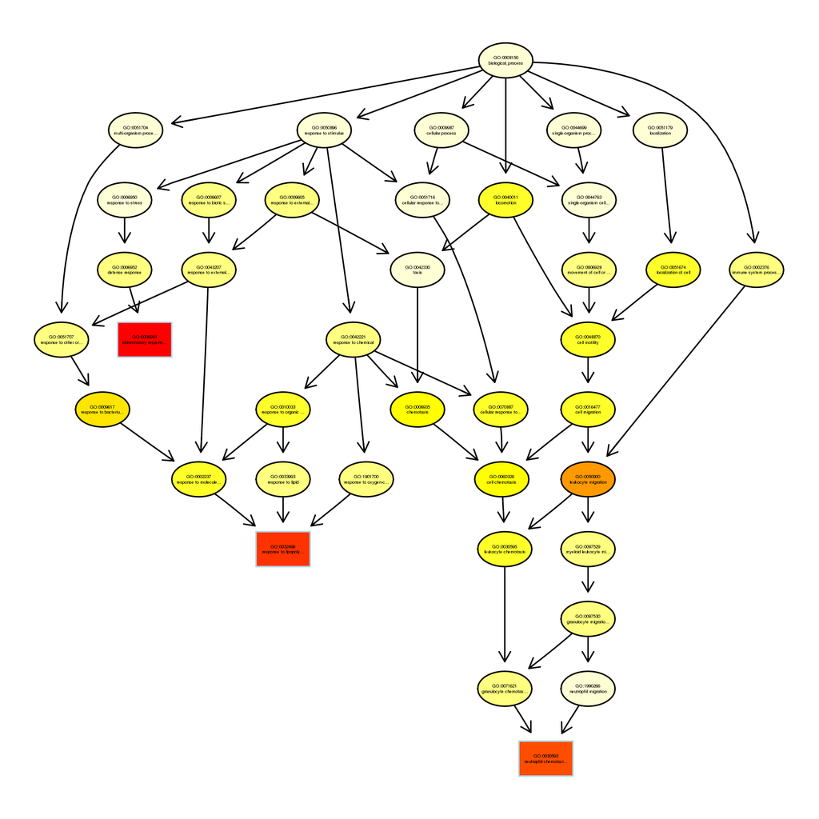

```
   $dag
   A graphNEL graph with directed edges
   Number of Nodes = 39
   Number of Edges = 57

   $complete.dag
   [1] "A graph with 39 nodes."
```

Gene set enrichment analysis has been and is a field of very extensive research in bioinformatics. For additional approaches see the *[topGO](http://bioconductor.org/packages/release/bioc/html/topGO.html)* vignette and the references therin and also in the [GeneSetEnrichment view](http://bioconductor.org/packages/release/BiocViews.html#___GeneSetEnrichment) .

# 9 A Pathway enrichment analysis using reactome

The package *[reactomePA](http://bioconductor.org/packages/release/bioc/html/reactomePA.html)* offers the possibility to test enrichment of specific pathways using the free, open-source, curated and peer reviewed pathway reactome pathway database. The package requires entrez IDs, so we convert out PROBEIDs to entrez IDs using the function `mapIDs` from the package *[AnnotationDBI](http://bioconductor.org/packages/release/bioc/html/AnnotationDBI.html)*. This will create a named vector that maps the PROBEIDs to the entrez ones.

```r
entrezIDs <- mapIds(hugene10sttranscriptcluster.db,
      keys = rownames(tableC),
       keytype="PROBEID",
       column = "ENTREZID")
```

We can now run the enrichment analysis that performs a statistical test based on the hypergeoemtric distribution that is the same as one sided Fisher–Test, which *[topGO](http://bioconductor.org/packages/release/bioc/html/topGO.html)* calls “Fisher–classic”. Details can be found in the vignette of the *[DOSE](http://bioconductor.org/packages/release/bioc/html/DOSE.html)* package.

```r
reactomeEnrich <- enrichPathway(gene = entrezIDs[DEgenesCD],
                                universe = entrezIDs[c(DEgenesCD, backG)],
                                organism = "human",
                                pvalueCutoff = 0.05,
                                qvalueCutoff = 0.9,
                                readable = TRUE)
# trim pathway names to 20 characters

reactomeEnrich@result$Description <- paste0(str_sub(reactomeEnrich@result$Description, 1, 20), "...")

head(summary(reactomeEnrich))[1:6]
```

```
              ID             Description GeneRatio  BgRatio   pvalue p.adjust
   202733 202733 Cell surface interac...   48/1272  80/4274 1.45e-08 1.52e-05
   380108 380108 Chemokine receptors ...   28/1272  39/4274 6.45e-08 3.37e-05
   168256 168256        Immune System...  265/1272 697/4274 1.90e-07 6.64e-05
   198933 198933 Immunoregulatory int...   28/1272  42/4274 7.53e-07 1.97e-04
   375276 375276 Peptide ligand-bindi...   50/1272  97/4274 4.54e-06 9.51e-04
   109582 109582           Hemostasis...  131/1272 320/4274 6.19e-06 1.08e-03
```

## 9.1 visualize the results

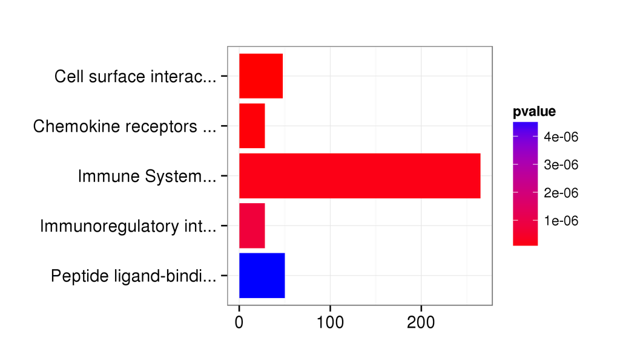

```r
barplot(reactomeEnrich)
```

The “enrichment map” displays the results of the enrichment analysis as a graph, where the color represents the p–value of the pathway and the edge–thickness is proportional to the number of overlapping genes between two pathways.

```r
enrichMap(reactomeEnrich, n = 20)
```

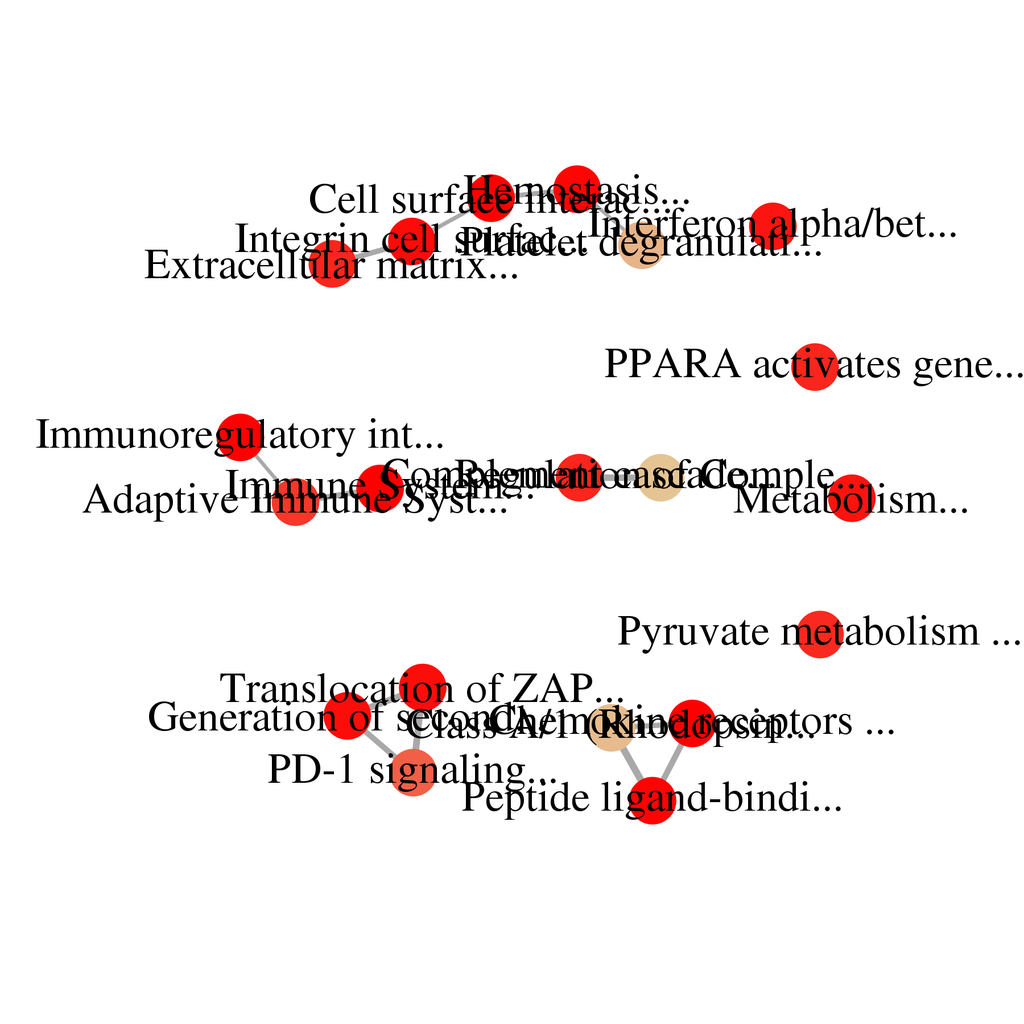

The package *[clusterProfiler](http://bioconductor.org/packages/release/bioc/html/clusterProfiler.html)* can also perform these analyses using downloaded KEGG data. Furthermore, the package *[enrichmentBrowser](http://bioconductor.org/packages/release/bioc/html/enrichmentBrowser.html)* additionally offers network–based enrichment analysis of indidividual pathways. This allows the mapping of the expression data at hand to known regulatory interactions.

# 10 Discussion and conclusion

We now remove the raw data directory again

```r
if(dir.exists(rawDataDir)){

    unlink(rawDataDir, recursive = TRUE)
}
```